# Titanic Machine Learning Models

# Introduction

This notebook applies machine learning approaches to the classic Titanic Passenger Survival Data Set (titanic). The steps follow the Titanic Exercises in section 5.3 of the HarvardX course PH125.8x Data Science: Machine Learning. (Note especially that seeds are set in order to match the expected output in the course materials).

## Load Data and Packages

The following R packages are necessary.

```r
library(titanic)
library(caret)
library(tidyverse)
library(rpart)
library(randomForest)
```

## Inspect Data

The titanic package includes separate test and train data. The models in this notebook will be applied to the training set, which includes 891 observations and 12 variables. A summary of the variables is shown below.

```r
print(summary(titanic_train))
```

```
##   PassengerId       Survived          Pclass          Name
##  Min.   :  1.0   Min.   :0.0000   Min.   :1.000   Length:891
##  1st Qu.:223.5   1st Qu.:0.0000   1st Qu.:2.000   Class :character
##  Median :446.0   Median :0.0000   Median :3.000   Mode  :character
##  Mean   :446.0   Mean   :0.3838   Mean   :2.309
##  3rd Qu.:668.5   3rd Qu.:1.0000   3rd Qu.:3.000
##  Max.   :891.0   Max.   :1.0000   Max.   :3.000
##
##      Sex                 Age            SibSp           Parch
##  Length:891         Min.   : 0.42   Min.   :0.000   Min.   :0.0000
##  Class :character   1st Qu.:20.12   1st Qu.:0.000   1st Qu.:0.0000
##  Mode  :character   Median :28.00   Median :0.000   Median :0.0000
##                     Mean   :29.70   Mean   :0.523   Mean   :0.3816
##                     3rd Qu.:38.00   3rd Qu.:1.000   3rd Qu.:0.0000
##                     Max.   :80.00   Max.   :8.000   Max.   :6.0000
##                     NA's   :177
##     Ticket               Fare           Cabin             Embarked
##  Length:891         Min.   :  0.00   Length:891         Length:891
##  Class :character   1st Qu.:  7.91   Class :character   Class :character
##  Mode  :character   Median : 14.45   Mode  :character   Mode  :character
##                     Mean   : 32.20
##                     3rd Qu.: 31.00
##                     Max.   :512.33
##
```

The Survived category represents the outcome that we will be predicting. Note that the mean 0.3838 represents the proportion of passengers that survived. Note also that the Age column includes 177 NA's, which will need to be replaced.

## Clean Data

Four tasks are completed to clean the data:

1. The Survived (Passenger Survival Indicator) and Embarked (Port of Embarkation) columns are transformed into factors.
2. The NA's in the Age column are replaced by the median.
3. The SibSp (Number of Siblings/Spouses Aboard) and Parch (Number of Parents/Children Aboard) columns are combined (+1 for the passenger) into a new metric called FamilySize .
4. A subset of eight variables is selected for modelling (PassengerId, Name, Ticket, and Cabin are dropped).

```r
titanic_clean <- titanic_train %>%
  mutate(Survived = factor(Survived),
         Embarked = factor(Embarked),
         Age = ifelse(is.na(Age), median(Age, na.rm = TRUE), Age), # NA age to median age
         FamilySize = SibSp + Parch + 1) %>%    # count family members
  select(Survived,  Sex, Pclass, Age, Fare, SibSp, Parch, FamilySize, Embarked)
```

## Partition Data

In order to test the models, train_data will itself be split 80/20 into two new dataframes, train_set and test_set. Each model will be fit to train_set and tested for accuracy on test_set.

```r
set.seed(42, sample.kind="Rounding")
test_index <- createDataPartition(titanic_clean$Survived, times = 1, p = 0.2, list = FALSE)
test_set <- titanic_clean[test_index, ]
train_set <- titanic_clean[-test_index, ]
y <- test_set$Survived     # Reference outcomes for testing
```

## Guessing?

Before training true machine learning models, we can set a baseline for performance by simply guessing whether each passenger survived or not.

```r
set.seed(3, sample.kind="Rounding")
y_hat_guess <- sample(c(0, 1), length(test_index), replace = TRUE) %>%
  factor(levels = levels(y))
cm_guess <-confusionMatrix(data = y_hat_guess, reference = y)
```

The accuracy of guessing is less than 50%.

```r
cm_guess$overall["Accuracy"]
```

```
##  Accuracy
## 0.4748603
```

# Building and Testing Models

In this section we will train several models. We will begin with a simple linear model using only one variable and slowly increase complexity.

## Women and Children First?

As we develop our model, a reasonable starting point is to assume that survival rates are strongly related to the variables Sex and Age. We will begin with Sex, as it is a simple categorical variable. As summarized below, the survival rate (Rate) does correlate strongly with gender in the train set--over 70% of female passengers survived compared to just under 20% of male passengers.

```r
train_set %>% group_by(Sex) %>% summarize(Rate = mean(Survived==1))
```

| Sex | Rate |
| --- | --- |
| female | 0.7309237 |
| male | 0.1965443 |

The following model predicts survival based solely on gender (if female y = 1, else y = 0).

```r
y_hat_gender <- ifelse(test_set$Sex == "female", 1, 0) %>% factor(levels = levels(y))
cm_gender <- confusionMatrix(data = y_hat_gender, reference = y)
```

The confusion matrix shows that false positives (14) and false negatives (18) are roughly equal.

```r
cm_gender$table
```

```
##           Reference
## Prediction  0  1
##          0 96 18
##          1 14 51
```

The accuracy of this simple model is 0.821.

```r
cm_gender$overall["Accuracy"]
```

```
##  Accuracy
## 0.8212291
```

## Passenger Class

Before thinking about Age, which is a continuous variable, we can add passenger class (Pclass) to the model. Pclass is also a simple categorical variable (1, 2, or 3), which seems to be a relatively strong predictor of survival when combined with gender. As the following summary shows, over 90% of female passengers in classes 1 and 2 survived.

```r
train_set %>% group_by(Sex, Pclass) %>% summarize(mean(Survived==1))
```

| Sex | Pclass | mean(Survived == 1) |
| --- | --- | --- |
| female | 1 | 0.9565217 |
| female | 2 | 0.9193548 |
| female | 3 | 0.5000000 |
| male | 1 | 0.3838384 |
| male | 2 | 0.1829268 |
| male | 3 | 0.1347518 |

When this insight is added to the simple model, however, the accuracy remains 0.821.

```r
y_hat_gender_class <- ifelse(test_set$Sex == "female" & (test_set$Pclass == 1 | test_set$Pclass == 2), 1, 0) %>%
  factor(levels = levels(y))
cm_gender_class <- confusionMatrix(data = y_hat_gender_class, reference = y)
cm_gender_class$overall["Accuracy"]
```

```
##  Accuracy
## 0.8212291
```

Moreover, there are other significant changes. The confusion matrix shows that we have virtually eliminated false positives (1) but at the cost of a significant increase in false negatives (31).

```r
cm_gender_class$table
```

```
##           Reference
## Prediction   0   1
##          0 109  31
##          1   1  38
```

This makes sense as we can predict survival for female passengers in classes 1 and 2 with great accuracy, but we are now predicting that female passengers in class 3 did not survive when half of them did.

As the following table shows, the sensitivity of the model is slightly increased by adding class, but specificity significantly decreases.

```r
comp <- data.frame(Sensitivity = c(cm_gender$byClass["Sensitivity"], cm_gender_class$byClass["Sensitivity"]), Specificity = c(cm_gender$byClass["Specificity"], cm_gender_class$byClass["Specificity"]))
rownames(comp) <- c("gender", "gender + class")
print(comp)
```

```
##                Sensitivity Specificity
## gender           0.8727273   0.7391304
## gender + class   0.9909091   0.5507246
```

## Age

Age is a continuous variable with a range of 0.4 to 80 and a mean of 29.7. On the whole, Age does not seem to correlate to survival.

```r
cor(as.numeric(train_set$Survived), train_set$Age)
```

```
## [1] -0.05456311
```

The approximate relationship can be observed by grouping Ages into bins of approximately equal size. Note that only the youngest passengers (< 17) have a survival rate over 50%.

```r
train_set %>% mutate(age_group = cut_number(Age, n = 8)) %>% group_by(age_group) %>% summarize(Rate = mean(Survived==1), Count = n())
```

| age_group | Rate | Count |
| --- | --- | --- |
| [0.42,17] | 0.5257732 | 97 |
| (17,22] | 0.3368421 | 95 |
| (22,27] | 0.3544304 | 79 |
| (27,28] | 0.2797619 | 168 |
| (28,29] | 0.4375000 | 16 |
| (29,35] | 0.4719101 | 89 |
| (35,45] | 0.4044944 | 89 |
| (45,80] | 0.3797468 | 79 |

We can try a logistic regression model (glm) to predict survival based on Age.

```r
set.seed(1, sample.kind="Rounding")
train_age_glm <- train(Survived ~ Age, method = "glm", data = train_set)
y_hat_age_glm <-  predict(train_age_glm, test_set)
cm_age_glm <- confusionMatrix(data = y_hat_age_glm, reference = y)
```

But note that this model simply predicts that no passengers survived!

```r
cm_age_glm$table
```

```
##           Reference
## Prediction   0   1
##          0 110  69
##          1   0   0
```

The accuracy of the model is 0.615. (Remember the overall survival rate is .384).

```r
cm_age_glm$overall["Accuracy"]
```

```
##  Accuracy
## 0.6145251
```

## Fare

```r
cor(as.numeric(train_set$Survived), train_set$Fare)
```

```
## [1] 0.2405983
```

For a quick view of the relationship, we can transform Fare into a categorical variable by grouping values into bins of approximately equal sizes. Note that the survival rate is only greater than 50% for the highest fare group (> 52).

```r
train_set %>% mutate(fare_group = cut_number(Fare, n = 6)) %>% group_by(fare_group) %>% summarize(Rate = mean(Survived==1), Count = n())
```

| fare_group | Rate | Count |
| --- | --- | --- |
| [0,7.78] | 0.2032520 | 123 |
| (7.78,8.43] | 0.1739130 | 115 |
| (8.43,14.5] | 0.3719008 | 121 |
| (14.5,26] | 0.4444444 | 117 |
| (26,52] | 0.4369748 | 119 |
| (52,512] | 0.6752137 | 117 |

We will try two models for fare: linear discriminant analysis (lda) and quadratic discriminant analysis (qda).

```r
# LDA Model
train_lda <- train(Survived ~ Fare, method = "lda", data = train_set)
y_hat_fare_lda <-  predict(train_lda, test_set)
cm_fare_lda <- confusionMatrix(data = y_hat_fare_lda, reference = y)

# QDA Model
set.seed(1, sample.kind="Rounding")
train_qda <- train(Survived ~ Fare, method = "qda", data = train_set)
y_hat_fare_qda <-  predict(train_qda, test_set)
cm_fare_qda <- confusionMatrix(data = y_hat_fare_qda, reference = y)
```

These models are basically identical, and result in the same low accuracy, 0.693.

```r
cm_fare_lda$table
```

```
##           Reference
## Prediction   0   1
##          0 106  51
##          1   4  18
```

```r
cm_fare_lda$overall["Accuracy"]
```

```
##  Accuracy
## 0.6927374
```

```r
cm_fare_qda$table
```

```
##           Reference
## Prediction   0   1
##          0 106  51
##          1   4  18
```

```r
cm_fare_qda$overall["Accuracy"]
```

```
##  Accuracy
## 0.6927374
```

## Logistic Regression with Multiple Variables

It is possible that a more accurate model could be built by considering multiple variables. The following model uses logistic regression with the four predictors we have explored to this point: Sex, Pclass, Fare, and Age.

```r
set.seed(1, sample.kind="Rounding")
x_train <- train_set %>% select(Sex, Pclass, Fare, Age)
y_train <- train_set$Survived
train_glm_1 <- train(x_train, y_train, method = "glm")
y_hat_glm_1 <-  predict(train_glm_1, test_set)
cm_glm_1 <- confusionMatrix(data = y_hat_glm_1, reference = y)
```

The accuracy of the model is 0.849, which is our highest score to this point, and an F1 score of 0.879.

```r
cm_glm_1$overall["Accuracy"]
```

```
## Accuracy
## 0.849162
```

```r
cm_glm_1$byClass["F1"]
```

```
##        F1
## 0.8789238
```

```r
cm_glm_1$table
```

```
##           Reference
## Prediction  0  1
##          0 98 15
##          1 12 54
```

```r
cm_glm_2$overall["Accuracy"]
```

[output not shown]

```
## Accuracy
## 0.849162
```

```r
cm_glm_2$byClass["F1"]
```

```
##        F1
## 0.8810573
```

## K-Nearest Neighbors

We can also try a k-nearest neighbors (knn) model using all variables. We will try odd values of k between 3 and 51.

```r
set.seed(6, sample.kind="Rounding")
train_knn <- train(Survived ~ ., method = "knn", tuneGrid = data.frame(k = seq(3, 51, 2)), data = train_set)
y_hat_knn <-  predict(train_knn, test_set)
cm_knn <- confusionMatrix(data = y_hat_knn, reference = y)
```

The model chose k = 11 as the optimal value.

```r
train_knn$bestTune
```

|  | k |
| --- | --- |
| 5 | 11 |

Unfortunately, this model is not an improvment over the logistic regression.

```r
cm_knn$overall["Accuracy"]
```

```
##  Accuracy
## 0.7094972
```

```r
cm_knn$byClass["F1"]
```

```
##        F1
## 0.7758621
```

Adding 10-fold cross-validation results in an optimal k = 5 but accuracy falls to 0.648.

```r
set.seed(8, sample.kind="Rounding")
control <- trainControl(method = "cv", number = 10, p = .9)
train_knn_cv <- train(Survived ~ ., method = "knn", tuneGrid = data.frame(k = seq(3, 51, 2)), data = train_set, trControl = control)
y_hat_knn_cv <-  predict(train_knn_cv, test_set)
cm_knn_cv <- confusionMatrix(data = y_hat_knn_cv, reference = y)
```

```r
cm_knn_cv$overall["Accuracy"]
```

```
##  Accuracy
## 0.6480447
```

```r
cm_knn_cv$byClass["F1"]
```

```
##        F1
## 0.7272727
```

## Regression Trees

A decision tree model can be built using regression trees (rpart). We will optimize the complexity parameter (cp) using values between 0 and 0.05.

```r
set.seed(10, sample.kind="Rounding")
train_rpart <- train(Survived ~ ., method = "rpart", tuneGrid = data.frame(cp = seq(0, 0.05, 0.002)), data = train_set)
y_hat_rpart <-  predict(train_rpart, test_set)
cm_rpart <- confusionMatrix(data = y_hat_rpart, reference = y)
```

The optimal value of cp was 0.016.

```r
train_rpart$bestTune
```

|  | cp |
| --- | --- |
| 9 | 0.016 |

The regression tree model resulted in an accuracy of 0.838 with an F1 score of 0.870. Both of these are slightly lower than the logistic regression.

```r
cm_rpart$overall["Accuracy"]
```

```
##  Accuracy
## 0.8379888
```

```r
cm_rpart$byClass["F1"]
```

```
##        F1
## 0.8699552
```

The decision tree of the final model can be plotted as below. Note that males are only predicted to survive if they are younger than 3.5, while females are predicted to survive if they are 1) in first or second class, or 2) have a fare price *under* $23.35. This result is slightly counter-intuitive as we might expect a higher fare to correlate with survival.

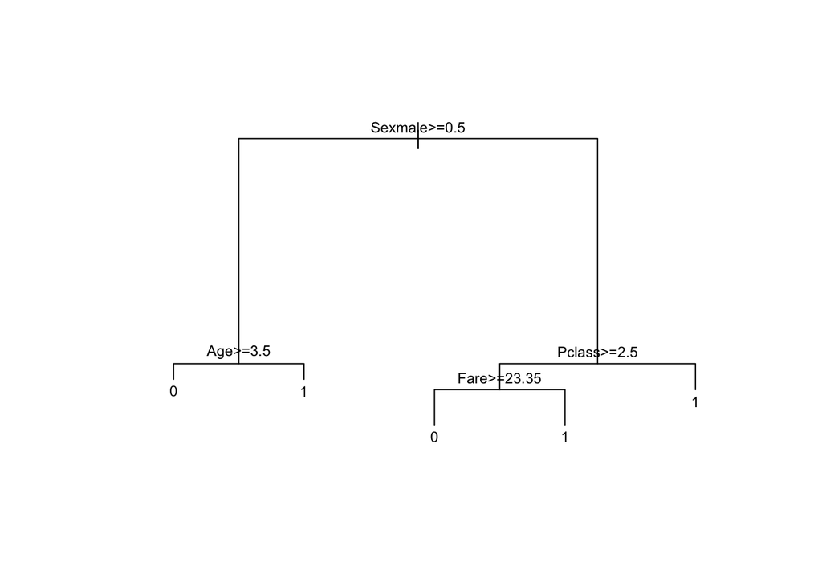

```r
plot(train_rpart$finalModel, margin = 0.1)
text(train_rpart$finalModel, cex = 0.75)
```

## Random Forest

A decision tree can also be created using the random forest model. We will optimze the tuning parameter mtry with values between 1 and 7 and limit the number of trees (ntree) to 100.

```r
set.seed(14, sample.kind="Rounding")
train_rf <- train(Survived ~ ., method = "rf", ntree = 100, tuneGrid = data.frame(mtry = 1:7), data = train_set)
y_hat_rf <-  predict(train_rf, test_set)
cm_rf <- confusionMatrix(data = y_hat_rf, reference = y)
```

The optimal value of mtry chosen by the model was 2.

```r
train_rf$bestTune
```

|  | mtry |
| --- | --- |
| 2 | 2 |

The random forest model resulted in an accuracy of 0.844 and an F1 score of 0.881.

```r
cm_rf$overall["Accuracy"]
```

```
##  Accuracy
## 0.8435754
```

```r
cm_rf$byClass["F1"]
```

```
##        F1
## 0.8813559
```

Examining the variable importance shows that Sex, Fare, Age, and Pclass are the most significant.

```r
varImp(train_rf)
```

```
## rf variable importance
##
##             Overall
## Sexmale    100.0000
## Fare        65.0909
## Age         45.5329
## Pclass      32.5289
## FamilySize  18.2748
## SibSp        7.8814
## Parch        7.1498
## EmbarkedS    2.8391
## EmbarkedQ    0.1218
## EmbarkedC    0.0000
```

## Conclusion

The best models seem to be logistic regression and random forest with F1 scores of.881.